# Projekt Dokumentation

### Umsatzprognose Bäckerfiale

#### Gruppe 12

#### Armando Criscuolo, Clara Urban

#### Git-Repository: https://github.com/xciax/ACTC

## Einleitung

Das Ziel dieser Projektdokumentation ist es, die grobe Struktur des Projekts zu erläutern, den ungefähren Ablauf der Arbeiten zu dokumentieren, die verwendeten Datensätze zu benennen und den geschriebenen Code, die verwendeten Tools und Methoden zur Datenaufbereitung sowie die Schritte zur Erstellung des neuronalen Netzes aufzuzeigen. Die verschiedenen Dateien des Projekts (Struktur) lassen sich in folgende Kategorien einordnen:

1. Die .R/.Rmd/.py Dateien, von der diese Datei die wichtigste ist, sind der Ort für die Datenaufbereitung, das NN und die Auswertung des NN. In dieser Datei hat die meiste Arbeit des Projekts stattgefunden und auf dieser basiert die zweit wichtigste Datei, nämlich die Projekt Päsentations: “Preasentation.Rmd”.
2. Die Datensatz Dateien mit den Endungen .Rda/.csv oder der Ordner “Facheinzelhandel_Umsatzt_SH”, in welchem die Excel Dateien gespeichert sind auf dem der Datensatz basiert, sind der Ort für die Speicherung unserer Daten für das Projekt.

Der Ablauf des Projekts lässt sich in drei verschiedene Phasen einteilen:

1. Installierung aller nötigen Umgebungen, Programme und Tools, sowie das lernen des vermittelten Wissens im Laufe des Kurses, sowie die Sammlung nützlicher (und weniger nütlicher) Datensätze, deren Aufbereitung und Erforschung.
2. Die endgültige Aufbereitung der Daten, deren Abstimmung auf das NN, das experemtiern, verbesseren und optimieren des NN und anderer Tools, anhand der gemessenen Performance des NN.
3. Feinschliff des NN und erstellen der Päsentation und Projekt Dokumentation.

## Verwendete Datensätze

#### (nicht Aufbereitet)

##### Gestellete Datensätze

1. Umsatz Daten: https://github.com/opencampus-sh/einfuehrung-in-data-science-und-ml/blob/main/umsatzdaten_gekuerzt.csv
2. Kieler Woche: https://github.com/opencampus-sh/einfuehrung-in-data-science-und-ml/blob/main/kiwo.csv
3. Wetter Daten: https://github.com/opencampus-sh/einfuehrung-in-data-science-und-ml/blob/main/wetter.csv

##### Selbst erstellte Datensätze

1. Schulferien SH: Manuell erstellt
2. Umsatz im Facheinzelhandel mit Nahrungsmitteln SH: https://www.govdata.de/web/guest/suchen/-/searchresult/f/groups%3Aecon%2Csourceportal%3A81b1a55a-02f7-42a5-a2b9-85698c6888c4%2Ctags%3Aentwicklung-im-einzelhandel-in-schleswig-holstein%2C/s/relevance_desc

### Benötigte Libraries laden

```r
# Remove all objects in the current environment
rm(list = ls())

# Create a list of needed packages
needed_packages <- c("lubridate", "stringr", "tidyverse", "readr",
                     "fastDummies", "reticulate", "ggplot2", "Metrics", "VIM", "synthpop", "httr", "styler")

# Iterate through the list of needed packages and check if they are installed
# If not, install them and load them into the environment
for (package in needed_packages) {
  if (!require(package, character.only = TRUE)) {
    install.packages(package)
    library(package, character.only = TRUE)
  }
}
```

```
✖ lubridate::as.difftime() masks base::as.difftime()
VIM is ready to use.

Suggestions and bug-reports can be submitted at: https://github.com/statistikat/VIM/issues


Find out more at https://www.synthpop.org.uk/
```

## Datenaufbereitung

### Vorbereitete Datensätze laden

Skripte, in denen die Daten aufbereitet wurden, und Namen der fertigen gespeicherten Datensätze:

1. Wetterdaten –> “Datenaufbereitung_Wetter.Rmd”
2. Feiertagedaten –> “Datenaufbereitung_Feiertage.R”
3. Schulferien –> “Datenaufbereitung_Schulferien.R”
4. Umsatzdaten –> “Datenaufbereitung_Umsatz.R”
5. Umsatzdaten aus dem Facheinzelhandel –> “Datenaufbereitung_FEH.R”

```r
load("pj_wetter_dummy.Rda")
pj_wetter <- pj_wetter_dummy

load("kiwoDT.Rda")
pj_kiwo <- kiwoDT

load("pj_umsatz.Rda")

load("schulferien.Rda")
pj_schulferien <- schulferien

load("umsatzFachEinzelHandelSH.Rda")
```

### Andere Datenaufbereitungs Datein

1. Extraktion der Umsatzdaten aus dem Facheinzelhandel: “xlxs_file_parsing.py”

### Erstellung des Trainingsdatensatzen “trainValidData” und “synTrainValidData”

#### (Zusammenführung der vorbereiteten Datensätze)

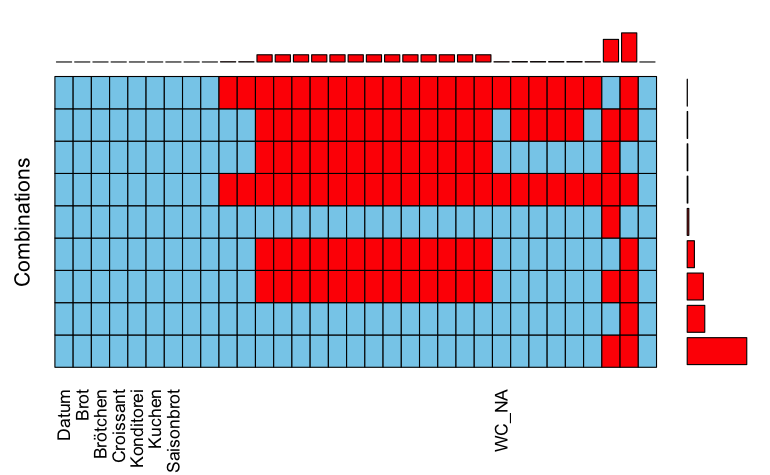

```r
# Merge the data sets
pj_umsatz_wetter <- merge(pj_umsatz, pj_wetter, by = "Datum", all.x = TRUE)
pj_umsatz_wetter_ferien <- merge(pj_umsatz_wetter, pj_schulferien, by = "Datum", all.x = TRUE)
allData <- merge(pj_umsatz_wetter_ferien, pj_kiwo, by = "Datum", all.x = TRUE)
allData <- merge(allData, umsatzFachEinzelHandelSH, by = "Datum", all.x = TRUE)

# Aggregate and impute missing data
allData_na <- allData %>%
  aggr(combined = TRUE, numbers = TRUE)
```

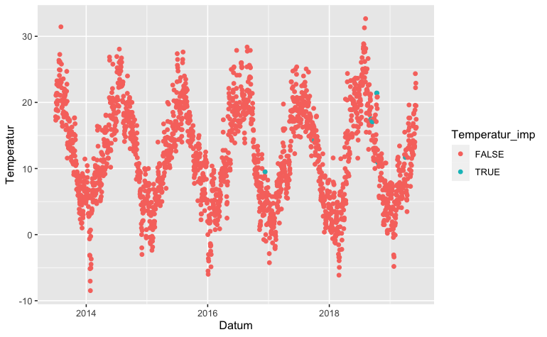

```r
allData <- allData %>%
  hotdeck(
    variable = c("Temperatur", "Windstaerke"),
    ord_var = "Datum"
  )

# Plot the data
ggplot(allData) +
  geom_point(aes(x = Datum, y = Temperatur, color = Temperatur_imp))
```

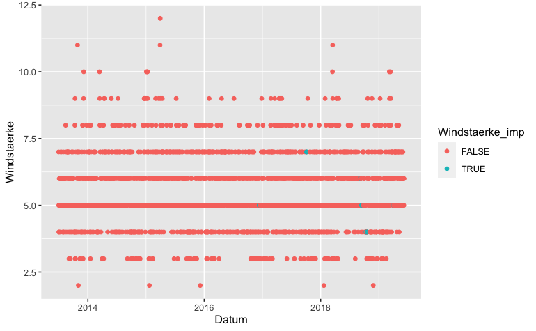

```r
ggplot(allData) +
  geom_point(aes(x = Datum, y = Windstaerke, color = Windstaerke_imp))
```

```r
# Replace missing data with zeroes
allData <- allData %>%
  mutate_at(c(12:34), ~ replace(., is.na(.), 0))

# Synthesize data using the synthpop package
synthpop_allData <- syn(allData)[["syn"]]
```

[output not shown]

```r
# Create dummy variables
allData_dummy <- dummy_cols(allData, select_columns = "Wochentag")
synthpop_allData_dummy <- dummy_cols(synthpop_allData, select_columns = "Wochentag")

# Extract year, month, and day from the date variable
allData_dummy$year <- year(allData_dummy$Datum)
allData_dummy$month <- month(allData_dummy$Datum)
allData_dummy$day <- day(allData_dummy$Datum)
synthpop_allData_dummy$year <- year(synthpop_allData_dummy$Datum)
synthpop_allData_dummy$month <- month(synthpop_allData_dummy$Datum)
synthpop_allData_dummy$day <- day(synthpop_allData_dummy$Datum)

# Save data sets
save(allData_dummy, file = "projectData_dummy_D.Rda")
save(synthpop_allData_dummy, file = "projectSynthpopData_dummy_D.Rda")

# Remove the date variable
allData_dummy$Datum <- NULL
synthpop_allData_dummy$Datum <- NULL

# Save data sets
save(allData_dummy, file = "projectData_dummy.Rda")
save(synthpop_allData_dummy, file = "projectSynthpopData_dummy.Rda")

# Rename Data Sets
trainValidData <- allData_dummy
synTrainValidData <- synthpop_allData_dummy
```

### Erstellung des Testdatensatzes für den Zeitraum vom 09.06 - 30.07.2019

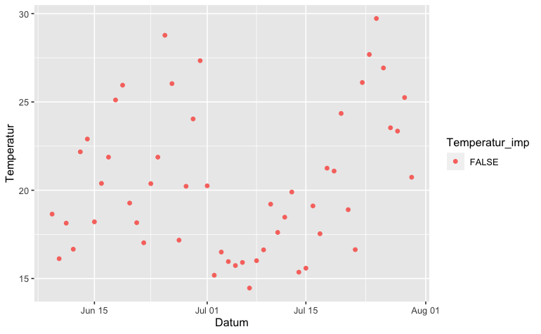

```r
# Create an empty data frame for test data
testDatenSatz <- data.frame(Datum = character())

# Create a sequence of dates
datum_sequenz <- seq(
  from = as.Date("2019-06-09"),
  to = as.Date("2019-07-30"),
  by = "days"
)

# Select specific columns from the pj_umsatz data set
sBrot <- select(pj_umsatz, "Datum", "Saisonbrot")

# Add the date sequence to the test data frame
testDatenSatz <- rbind(testDatenSatz, data.frame(Datum = datum_sequenz))

# Add the day of the week to the test data frame
testDatenSatz$Wochentag <- weekdays(testDatenSatz$Datum)

# Merge the test data frame with other data sets
testDatenSatz <- merge(testDatenSatz, pj_wetter, by = "Datum", all.x = TRUE)
testDatenSatz <- merge(testDatenSatz, pj_schulferien, by = "Datum", all.x = TRUE)
testDatenSatz <- merge(testDatenSatz, pj_kiwo, by = "Datum", all.x = TRUE)
testDatenSatz <- merge(testDatenSatz, sBrot, by = "Datum", all.x = TRUE)
testDatenSatz <- merge(testDatenSatz, umsatzFachEinzelHandelSH, by = "Datum", all.x = TRUE)

# Impute missing data
testDatenSatz <- testDatenSatz %>%
  hotdeck(
    variable = c("Temperatur", "Windstaerke"),
    ord_var = "Datum"
  )

# Plot the data
ggplot(testDatenSatz) +
  geom_point(aes(x = Datum, y = Temperatur, color = Temperatur_imp))
```

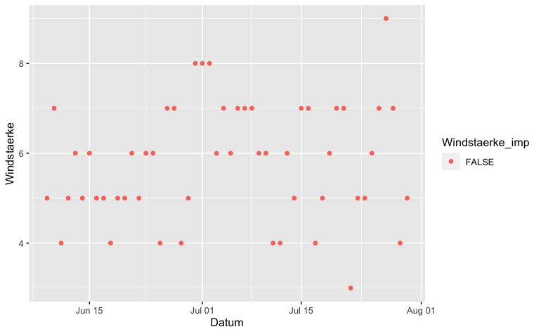

```r
ggplot(testDatenSatz) +
  geom_point(aes(x = Datum, y = Windstaerke, color = Windstaerke_imp))
```

```r
# Replace missing data with zeroes
testDatenSatz <- testDatenSatz %>%
  mutate_at(c(4:26), ~ replace(., is.na(.), 0))

# Create dummy variables
testDatenSatz <- dummy_cols(testDatenSatz, select_columns = "Wochentag")

# Extract year, month, and day from the date variable
testDatenSatz$year <- year(testDatenSatz$Datum)
testDatenSatz$month <- month(testDatenSatz$Datum)
testDatenSatz$day <- day(testDatenSatz$Datum)

# Remove the date and day of the week variables
testDatenSatz$Datum <- NULL
testDatenSatz$Wochentag <- NULL

# Save the test data set
#save(testDatenSatz, file = "Datenaufbereitung_Testdaten.Rda")
```

## Optimierung des neuronalen Netzes

### Features & Labels

```r
# Define the features for the model
features <- c(
  "day", "month", "year",
  "Windstaerke", "Temperatur", "WC_Bewölkung_abnehmend",
  "WC_Bewölkung_gleichbleibend", "WC_Bewölkung_nicht_beobachtet", "WC_Bewölkung_zunehmend",
  "WC_Dunst_Staub", "WC_Ereignisse_letzte_h", "WC_Gewitter",
  "WC_Nebel_Eisnebel", "WC_Regen", "WC_Schauer",
  "WC_Schnee", "WC_Sprühregen", "WC_Trockenereignisse",
  "WC_NA", "Bewoelkungsgrad_gering", "Bewoelkungsgrad_keine",
  "Bewoelkungsgrad_mittel", "Bewoelkungsgrad_stark", "Bewoelkungsgrad_NA",
  "Schulferien", "KielerWoche",
  "Wochentag_Tuesday",
  "Wochentag_Thursday", "Saisonbrot", "UmsatzFEH",
  "Wochentag_Friday", "Wochentag_Wednesday", "Wochentag_Monday",
  "Wochentag_Saturday", "Wochentag_Sunday"
)

# Define the labels for the model
labels <- c("Brot", "Brötchen", "Croissant", "Konditorei", "Kuchen")
```

### Selektion der Trainings, Validirungs und Test Daten

```r
# Set seed for reproducibility
set.seed(1)

# Assign samples to train, validation and test sets
assignment <- sample(1:3, size = nrow(trainValidData), prob = c(.7, .2, .1), replace = TRUE)

# Create new training data set by binding samples from original training data and synthetic data
trainValidData2 <- rbind(trainValidData[assignment == 1, ], synTrainValidData)

# Extract features and labels for training, validation and testing sets
training_features <- trainValidData2[, features]
training_labels <- trainValidData2[, labels]

validation_features <- trainValidData[assignment == 2, features]
validation_labels <- trainValidData[assignment == 2, labels]

testing_features <- trainValidData[assignment == 3, features]
testing_labels <- trainValidData[assignment == 3, labels]

# Check for any missing data in each set
#table(is.na(training_features))
#table(is.na(validation_features))
#table(is.na(testing_features))
```

### Modell aufstellen in Python

```python
reticulate::repl_python()
import numpy as np
import tensorflow as tf
from tensorflow.keras.models import Sequential
from tensorflow.keras.layers import InputLayer, Dense, BatchNormalization, Dropout
from tensorflow.keras.optimizers import Adam

# Initialize the model
model = Sequential([
  # Input layer with the shape of the input data
  InputLayer(input_shape = (len(r.training_features.keys()), )),
  # Batch normalization layer
  BatchNormalization(),
  # First dense layer with swish activation function
  Dense(len(r.training_features.keys()), activation = 'swish'),
  # Dropout layer with rate 0.2
  Dropout(0.2),
  # Second dense layer with swish activation function
  Dense(len(r.training_features.keys()), activation = 'swish'),
  # Dropout layer with rate 0.2
  Dropout(0.2),
  # Third dense layer with swish activation function
  Dense(len(r.training_features.keys()), activation = 'swish'),
  # Output layer with 5 units
  Dense(5)
])

# Print a summary of the model's architecture
model.summary()
```

```
Model: "sequential"
_________________________________________________________________
 Layer (type)                Output Shape              Param #
=================================================================
 batch_normalization (BatchN  (None, 35)               140
 ormalization)

 dense (Dense)               (None, 35)                1260

 dropout (Dropout)           (None, 35)                0

 dense_1 (Dense)             (None, 35)                1260

 dropout_1 (Dropout)         (None, 35)                0

 dense_2 (Dense)             (None, 35)                1260

 dense_3 (Dense)             (None, 5)                 180

=================================================================
Total params: 4,100
Trainable params: 4,030
Non-trainable params: 70
_________________________________________________________________
```

### Schätzung de neuronalen Netzes

```python
# Compile the model
model.compile(loss="mape", optimizer=Adam(learning_rate=0.001))

# Fit the model to the training data
history = model.fit(r.training_features, r.training_labels, epochs=200,
                    validation_data = (r.validation_features, r.validation_labels), verbose=0)
```

```
2023-01-25 11:49:33.636149: W tensorflow/core/platform/profile_utils/cpu_utils.cc:128] Failed to get CPU frequency: 0 Hz
```

```python
# Save the model to a file
model.save("python_model.h5")
```

### graphische Ausgabe der Modelloptimierung

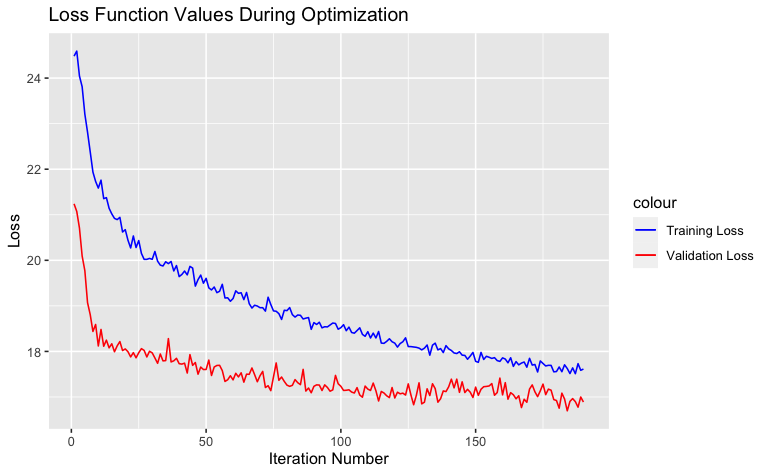

```r
quit
data <- data.frame(
  val_loss = unlist(py$history$history$val_loss),
  loss = unlist(py$history$history$loss)
)

# Plot the loss values for both training and validation data
ggplot(data[-(1:10), ]) +
  geom_line(aes(x = 1:length(val_loss), y = val_loss, colour = "Validation Loss")) +
  geom_line(aes(x = 1:length(loss), y = loss, colour = "Training Loss")) +
  # Specify colors for the lines
  scale_colour_manual(values = c("Training Loss" = "blue", "Validation Loss" = "red")) +
  # Add title and axis labels
  labs(title = "Loss Function Values During Optimization") +
  xlab("Iteration Number") +
  ylab("Loss")
```

### Auswertung der Schätzergebnisse

```r
# Predictions
training_predictions <- py$model$predict(training_features)
validation_predictions <- py$model$predict(validation_features)
testing_predictions <- py$model$predict(testing_features)
# MAPE
a <- format(mape(training_labels[, 1], training_predictions[, 1]) * 100, digits = 3, nsmall = 2)
b <- format(mape(training_labels[, 2], training_predictions[, 2]) * 100, digits = 3, nsmall = 2)
c <- format(mape(training_labels[, 3], training_predictions[, 3]) * 100, digits = 3, nsmall = 2)
d <- format(mape(training_labels[, 4], training_predictions[, 4]) * 100, digits = 3, nsmall = 2)
e <- format(mape(training_labels[, 5], training_predictions[, 5]) * 100, digits = 3, nsmall = 2)

cat(paste0("\nMAPE on the Training Data1:\t", a))
```

```
MAPE on the Training Data1: 18.13
```

```r
cat(paste0("\nMAPE on the Training Data2:\t", b))
```

```
MAPE on the Training Data2: 12.04
```

```r
cat(paste0("\nMAPE on the Training Data3:\t", c))
```

```
MAPE on the Training Data3: 17.15
```

```r
cat(paste0("\nMAPE on the Training Data4:\t", d))
```

```
MAPE on the Training Data4: 21.23
```

```r
cat(paste0("\nMAPE on the Training Data5:\t", e, "\n"))
```

```
MAPE on the Training Data5: 13.56
```

```r
g <- format(mape(validation_labels[, 1], validation_predictions[, 1]) * 100, digits = 3, nsmall = 2)
h <- format(mape(validation_labels[, 2], validation_predictions[, 2]) * 100, digits = 3, nsmall = 2)
i <- format(mape(validation_labels[, 3], validation_predictions[, 3]) * 100, digits = 3, nsmall = 2)
j <- format(mape(validation_labels[, 4], validation_predictions[, 4]) * 100, digits = 3, nsmall = 2)
k <- format(mape(validation_labels[, 5], validation_predictions[, 5]) * 100, digits = 3, nsmall = 2)

cat(paste0("\nMAPE on the Validation Data1:\t", g))
```

```
MAPE on the Validation Data1:   18.80
```

```r
cat(paste0("\nMAPE on the Validation Data2:\t", h))
```

```
MAPE on the Validation Data2:   12.29
```

```r
cat(paste0("\nMAPE on the Validation Data3:\t", i))
```

```
MAPE on the Validation Data3:   18.99
```

```r
cat(paste0("\nMAPE on the Validation Data4:\t", j))
```

```
MAPE on the Validation Data4:   20.01
```

```r
cat(paste0("\nMAPE on the Validation Data5:\t", k, "\n"))
```

```
MAPE on the Validation Data5:   14.36
```

```r
l <- format(mape(testing_labels[, 1], testing_predictions[, 1]) * 100, digits = 3, nsmall = 2)
m <- format(mape(testing_labels[, 2], testing_predictions[, 2]) * 100, digits = 3, nsmall = 2)
n <- format(mape(testing_labels[, 3], testing_predictions[, 3]) * 100, digits = 3, nsmall = 2)
o <- format(mape(testing_labels[, 4], testing_predictions[, 4]) * 100, digits = 3, nsmall = 2)
p <- format(mape(testing_labels[, 5], testing_predictions[, 5]) * 100, digits = 3, nsmall = 2)

cat(paste0("\nMAPE on the Validation Data1:\t", l))
```

```
MAPE on the Validation Data1:   18.89
```

```r
cat(paste0("\nMAPE on the Validation Data2:\t", m))
```

```
MAPE on the Validation Data2:   13.40
```

```r
cat(paste0("\nMAPE on the Validation Data3:\t", n))
```

```
MAPE on the Validation Data3:   20.40
```

```r
cat(paste0("\nMAPE on the Validation Data4:\t", o))
```

```
MAPE on the Validation Data4:   21.77
```

```r
cat(paste0("\nMAPE on the Validation Data5:\t", p, "\n"))
```

```
MAPE on the Validation Data5:   13.34
```

```r
# Mean of Training and Validation Data MAPE
meanT <- c(as.double(a), as.double(b), as.double(c), as.double(d), as.double(e))
meanV <- c(as.double(g), as.double(h), as.double(i), as.double(j), as.double(k))
meanT <- c(as.double(l), as.double(m), as.double(n), as.double(o), as.double(p))

cat(paste0("\nMean Training MAPE: ", mean(meanT), "\n"))
```

[output not shown]

```r
cat(paste0("Mean Validation MAPE: ", mean(meanV), "\n"))
```

```
Mean Validation MAPE: 16.89
```

```r
cat(paste0("Mean Test MAPE: ", mean(meanT), "\n"))
```

```
Mean Test MAPE: 17.56
```

### Grafischer vergleich der vorhergesagten & tatsächlicher Preise für die Trainings- und Validierungsdaten

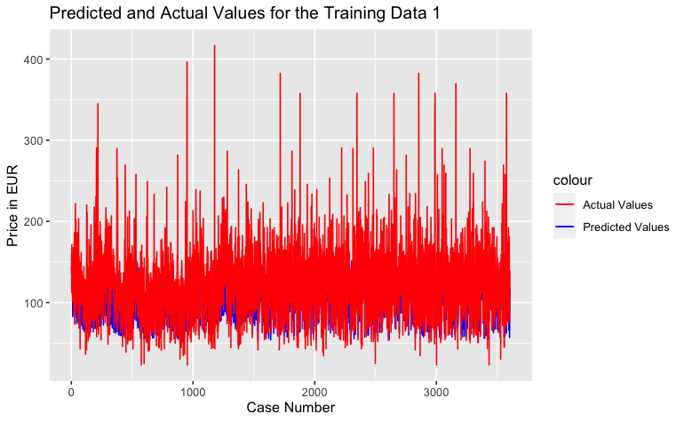

```r
data_train <- data.frame(prediction = training_predictions[, 1], actual = training_labels[, 1])
data_val <- data.frame(prediction = validation_predictions[, 1], actual = validation_labels[, 1])
data_test <- data.frame(prediction = testing_predictions[, 1], actual = testing_labels[, 1])

#------------------------- Warengruppe 1 -------------------------#

# Plot der Ergebnisse der Trainingsdaten
ggplot(data_train[]) +
  geom_line(aes(x = 1:length(prediction), y = prediction, colour = "Predicted Values")) +
  geom_line(aes(x = 1:length(actual), y = actual, colour = "Actual Values")) +
  scale_colour_manual(values = c("Predicted Values" = "blue", "Actual Values" = "red")) +
  labs(title = "Predicted and Actual Values for the Training Data 1") +
  xlab("Case Number") +
  ylab("Price in EUR")
```

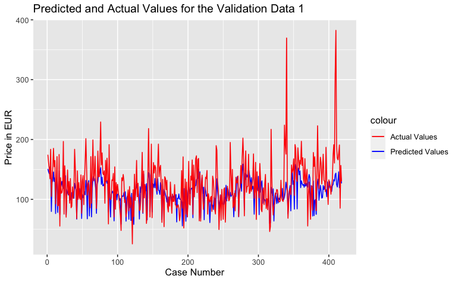

```r
# Plot der Ergebnisse der Validierungsdaten
ggplot(data_val[, ]) +
  geom_line(aes(x = 1:length(prediction), y = prediction, colour = "Predicted Values")) +
  geom_line(aes(x = 1:length(actual), y = actual, colour = "Actual Values")) +
  scale_colour_manual(values = c("Predicted Values" = "blue", "Actual Values" = "red")) +
  labs(title = "Predicted and Actual Values for the Validation Data 1") +
  xlab("Case Number") +
  ylab("Price in EUR")
```

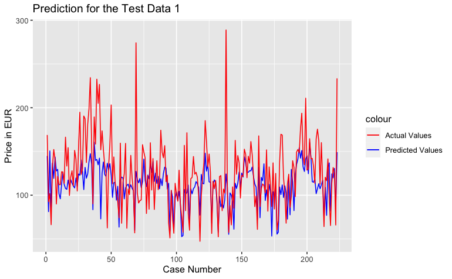

```r
# Plot der Ergebnisse der Testdaten
ggplot(data_test) +
  geom_line(aes(x = 1:length(prediction), y = prediction, colour = "Predicted Values")) +
  geom_line(aes(x = 1:length(actual), y = actual, colour = "Actual Values")) +
  scale_colour_manual(values = c("Predicted Values" = "blue", "Actual Values" = "red")) +
  labs(title = "Prediction for the Test Data 1") +
  xlab("Case Number") +
  ylab("Price in EUR")
```

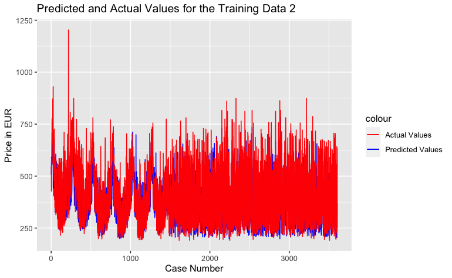

```r
#------------------------- Warengruppe 2 -------------------------#

data_train2 <- data.frame(prediction = training_predictions[, 2], actual = training_labels[, 2])
data_val2 <- data.frame(prediction = validation_predictions[, 2], actual = validation_labels[, 2])
data_test2 <- data.frame(prediction = testing_predictions[, 2], actual = testing_labels[, 2])

# Plot der Ergebnisse der Trainingsdaten
ggplot(data_train2) +
  geom_line(aes(x = 1:length(prediction), y = prediction, colour = "Predicted Values")) +
  geom_line(aes(x = 1:length(actual), y = actual, colour = "Actual Values")) +
  scale_colour_manual(values = c("Predicted Values" = "blue", "Actual Values" = "red")) +
  labs(title = "Predicted and Actual Values for the Training Data 2") +
  xlab("Case Number") +
  ylab("Price in EUR")
```

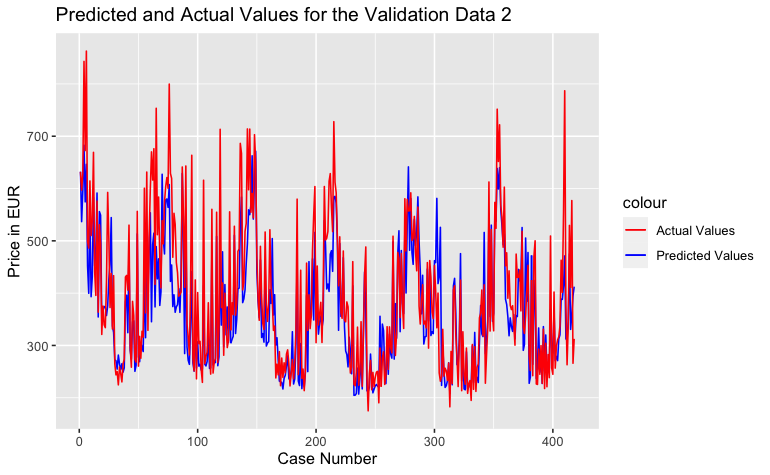

```r
# Plot der Ergebnisse der Validierungsdaten
ggplot(data_val2) +
  geom_line(aes(x = 1:length(prediction), y = prediction, colour = "Predicted Values")) +
  geom_line(aes(x = 1:length(actual), y = actual, colour = "Actual Values")) +
  scale_colour_manual(values = c("Predicted Values" = "blue", "Actual Values" = "red")) +
  labs(title = "Predicted and Actual Values for the Validation Data 2") +
  xlab("Case Number") +
  ylab("Price in EUR")
```

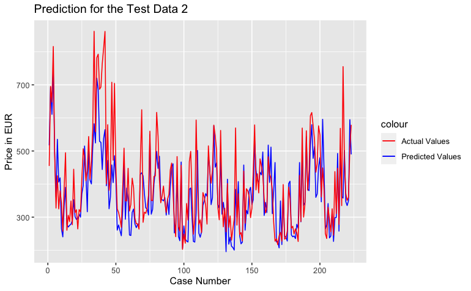

```r
# Plot der Ergebnisse der Testdaten
ggplot(data_test2) +
  geom_line(aes(x = 1:length(prediction), y = prediction, colour = "Predicted Values")) +
  geom_line(aes(x = 1:length(actual), y = actual, colour = "Actual Values")) +
  scale_colour_manual(values = c("Predicted Values" = "blue", "Actual Values" = "red")) +
  labs(title = "Prediction for the Test Data 2") +
  xlab("Case Number") +
  ylab("Price in EUR")
```

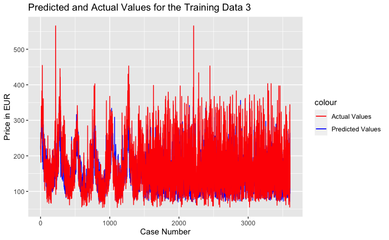

```r
#------------------------- Warengruppe 3 -------------------------#

data_train3 <- data.frame(prediction = training_predictions[, 3], actual = training_labels[, 3])
data_val3 <- data.frame(prediction = validation_predictions[, 3], actual = validation_labels[, 3])
data_test3 <- data.frame(prediction = testing_predictions[, 3], actual = testing_labels[, 3])

# Plot der Ergebnisse der Trainingsdaten
ggplot(data_train3) +
  geom_line(aes(x = 1:length(prediction), y = prediction, colour = "Predicted Values")) +
  geom_line(aes(x = 1:length(actual), y = actual, colour = "Actual Values")) +
  scale_colour_manual(values = c("Predicted Values" = "blue", "Actual Values" = "red")) +
  labs(title = "Predicted and Actual Values for the Training Data 3") +
  xlab("Case Number") +
  ylab("Price in EUR")
```

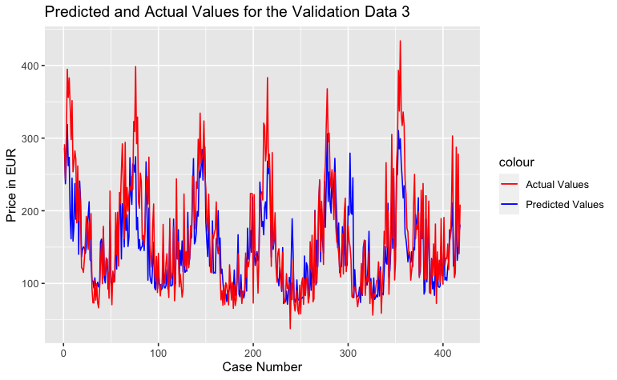

```r
# Plot der Ergebnisse der Validierungsdaten
ggplot(data_val3) +
  geom_line(aes(x = 1:length(prediction), y = prediction, colour = "Predicted Values")) +
  geom_line(aes(x = 1:length(actual), y = actual, colour = "Actual Values")) +
  scale_colour_manual(values = c("Predicted Values" = "blue", "Actual Values" = "red")) +
  labs(title = "Predicted and Actual Values for the Validation Data 3") +
  xlab("Case Number") +
  ylab("Price in EUR")
```

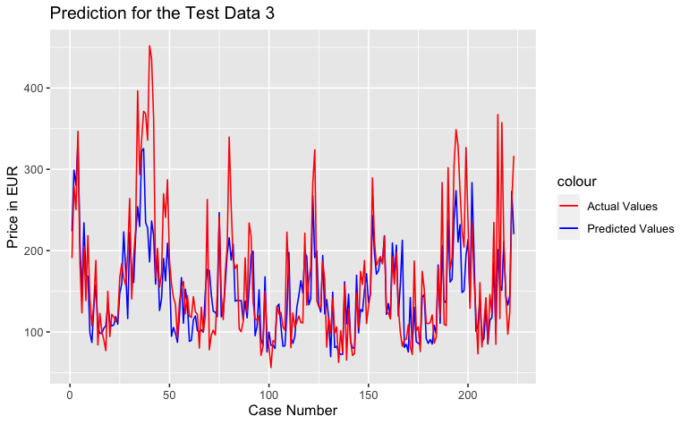

```r
# Plot der Ergebnisse der Testdaten
ggplot(data_test3) +
  geom_line(aes(x = 1:length(prediction), y = prediction, colour = "Predicted Values")) +
  geom_line(aes(x = 1:length(actual), y = actual, colour = "Actual Values")) +
  scale_colour_manual(values = c("Predicted Values" = "blue", "Actual Values" = "red")) +
  labs(title = "Prediction for the Test Data 3") +
  xlab("Case Number") +
  ylab("Price in EUR")
```

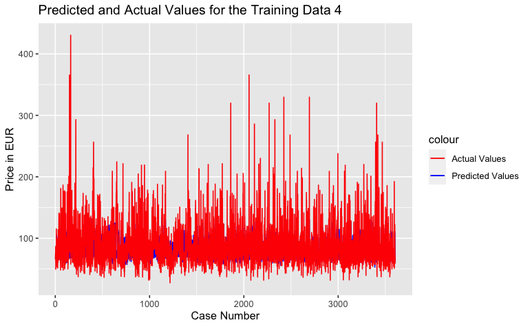

```r
#------------------------- Warengruppe 4 -------------------------#

data_train4 <- data.frame(prediction = training_predictions[, 4], actual = training_labels[, 4])
data_val4 <- data.frame(prediction = validation_predictions[, 4], actual = validation_labels[, 4])
data_test4 <- data.frame(prediction = testing_predictions[, 4],actual = testing_labels[, 4])

# Plot der Ergebnisse der Trainingsdaten
ggplot(data_train4) +
  geom_line(aes(x = 1:length(prediction), y = prediction, colour = "Predicted Values")) +
  geom_line(aes(x = 1:length(actual), y = actual, colour = "Actual Values")) +
  scale_colour_manual(values = c("Predicted Values" = "blue", "Actual Values" = "red")) +
  labs(title = "Predicted and Actual Values for the Training Data 4") +
  xlab("Case Number") +
  ylab("Price in EUR")
```

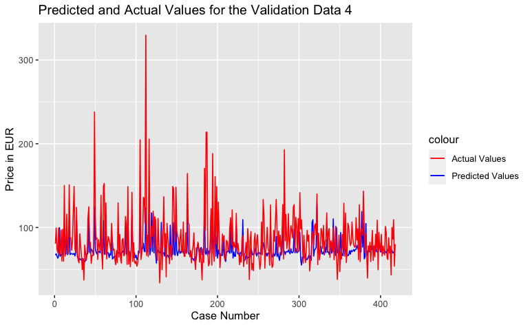

```r
# Plot der Ergebnisse der Validierungsdaten
ggplot(data_val4) +
  geom_line(aes(x = 1:length(prediction), y = prediction, colour = "Predicted Values")) +
  geom_line(aes(x = 1:length(actual), y = actual, colour = "Actual Values")) +
  scale_colour_manual(values = c("Predicted Values" = "blue", "Actual Values" = "red")) +
  labs(title = "Predicted and Actual Values for the Validation Data 4") +
  xlab("Case Number") +
  ylab("Price in EUR")
```

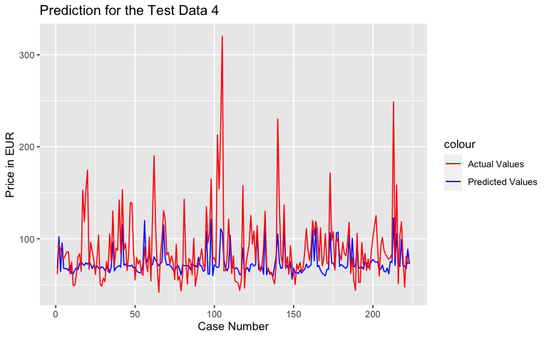

```r
# Plot der Ergebnisse der Testdaten
ggplot(data_test4) +
  geom_line(aes(x = 1:length(prediction), y = prediction, colour = "Predicted Values")) +
  geom_line(aes(x = 1:length(actual), y = actual, colour = "Actual Values")) +
  scale_colour_manual(values = c("Predicted Values" = "blue", "Actual Values" = "red")) +
  labs(title = "Prediction for the Test Data 4") +
  xlab("Case Number") +
  ylab("Price in EUR")
```

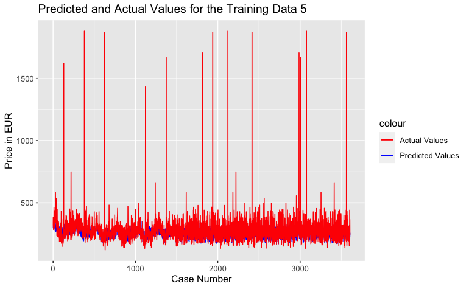

```r
#------------------------- Warengruppe 5 -------------------------#

data_train5 <- data.frame(prediction = training_predictions[, 5], actual = training_labels[, 5])
data_val5 <- data.frame(prediction = validation_predictions[, 5], actual = validation_labels[, 5])
data_test5 <- data.frame(prediction = testing_predictions[, 5], actual = testing_labels[, 5])

# Plot der Ergebnisse der Trainingsdaten
ggplot(data_train5) +
  geom_line(aes(x = 1:length(prediction), y = prediction, colour = "Predicted Values")) +
  geom_line(aes(x = 1:length(actual), y = actual, colour = "Actual Values")) +
  scale_colour_manual(values = c("Predicted Values" = "blue", "Actual Values" = "red")) +
  labs(title = "Predicted and Actual Values for the Training Data 5") +
  xlab("Case Number") +
  ylab("Price in EUR")
```

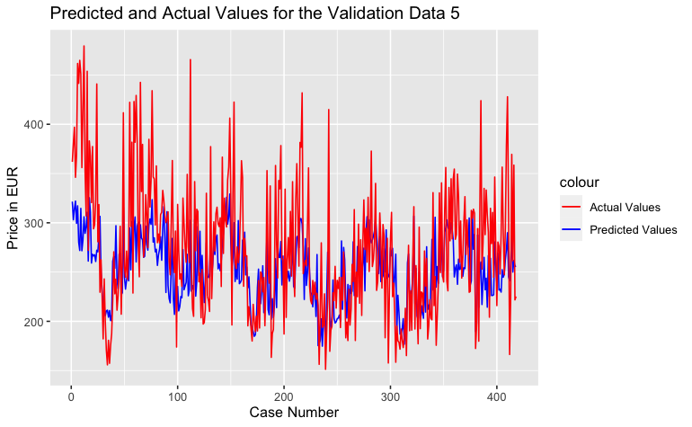

```r
# Plot der Ergebnisse der Validierungsdaten
ggplot(data_val5) +
  geom_line(aes(x = 1:length(prediction), y = prediction, colour = "Predicted Values")) +
  geom_line(aes(x = 1:length(actual), y = actual, colour = "Actual Values")) +
  scale_colour_manual(values = c("Predicted Values" = "blue", "Actual Values" = "red")) +
  labs(title = "Predicted and Actual Values for the Validation Data 5") +
  xlab("Case Number") +
  ylab("Price in EUR")
```

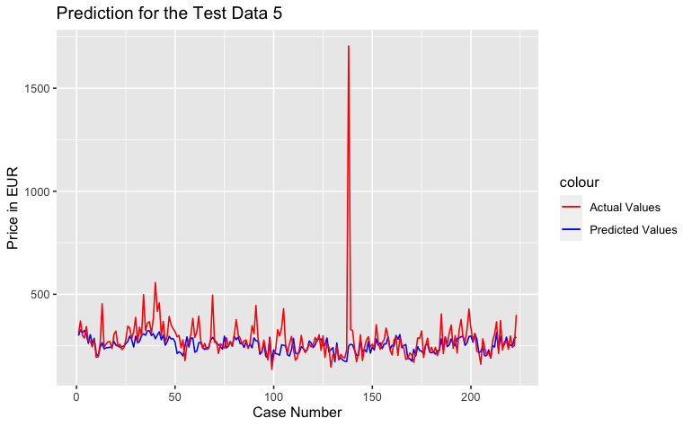

```r
# Plot der Ergebnisse der Testdaten
ggplot(data_test5) +
  geom_line(aes(x = 1:length(prediction), y = prediction, colour = "Predicted Values")) +
  geom_line(aes(x = 1:length(actual), y = actual, colour = "Actual Values")) +
  scale_colour_manual(values = c("Predicted Values" = "blue", "Actual Values" = "red")) +
  labs(title = "Prediction for the Test Data 5") +
  xlab("Case Number") +
  ylab("Price in EUR")
```